[figure not shown]

CURSO SOBRE BIOHERRAMIENTAS EN BIOESTADISTICA Y BIOINFORMATICA  
(1ªEdición)

Barcelona, 16, 17 y 18 de Mayo 2017

Cómo crear aplicaciones con Shiny

Parte IV: maneras de mejorar la aplicación

### Inserir código HTML y CSS

- Usando la función **`HTML`** se pueden escribir código HTML para cambiar el estilo (color, tamaño, poner links, etc.) en un texto.
- En la cabecera se pueden especificar los estilos de objetos (#elemento) que son aplicados a los elementos de entrada a partir de su id'.
- También se puede especificar la etiqueta de cualquier elemento de entrada con la función **`HTML`** para inserir textos con enlaces, etc.

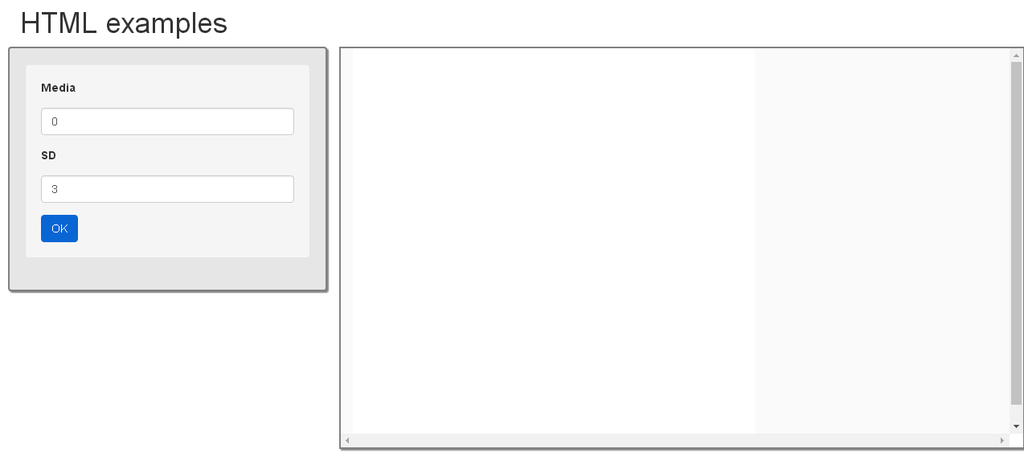

Fíjate qué pasa al posicionar el ratón encima de las etiquetas de los inputs (media ó sd).

```r
ui <- fluidPage(
  headerPanel("HTML examples"),

  HTML("<style type='text/css'> #inputpanel{background-color: rgb(230,230,230);
       border: 2px solid grey; box-shadow: 2px 2px 1px #888888;} </style>"),
  HTML("<style type='text/css'> #outpanel { background-color: rgb(250,250,250);
       border: 2px solid grey; box-shadow: 2px 2px 1px #888888; overflow:scroll; height:500px} </style>"),
  HTML("<style type='text/css'> #OK {color:white; background-color:rgb(10,101,212);
       border: solid 1px rgb(10,101,212)} </style>"),
  HTML("<style type='text/css'> #inputpanel .wellPanel {background-color:rgb(215,215,215); </style>"),

  sidebarLayout(
    sidebarPanel(id="inputpanel",
      wellPanel(
        numericInput("media", HTML("<p title='Introduce la media'>Media</p>"), 0),
        numericInput("sd", HTML("<p title='Introduce la desviación estándar'>SD</p>"),3),
        actionButton("OK", "OK")
      )
    ),
    mainPanel(id="outpanel",
      plotOutput("results")
    )
  )
)

server <- function(input,output){
  output$results <- renderPlot({
    if (input$OK == 0) return(invisible(NULL))
    isolate({
      hist(rnorm(100, input$media, input$sd), xlab="var", ylab = "frec", main = "")
    })
  }, 500, 500)
}

shinyApp(ui=ui,server=server)
```

### Creación "Pop-ups"

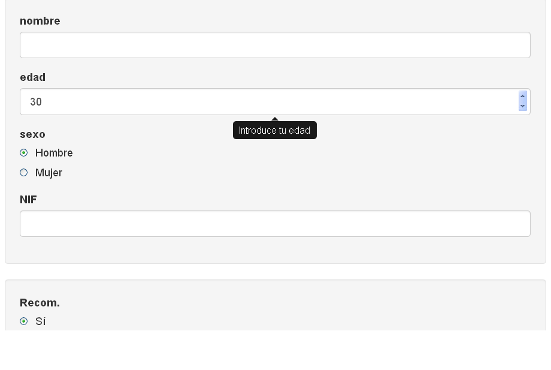

```r
library(shinyBS)

ui <- fluidPage(
  wellPanel(id="person",
    textInput("nombre", "nombre", ""),
    numericInput("edad", "edad", 30),
    radioButtons("sexo", "sexo", c("Hombre", "Mujer")),
    textInput("dni", "NIF", "")
  ),
  wellPanel(id="product",
    radioButtons("recom", "Recom.", c("Sí", "No")),
    sliderInput("valor", "Valoración", 0, 10, 5)
  ),
  bsTooltip("nombre", "Escribe tu nombre y apellidos"),
  bsTooltip("edad", "Introduce tu edad"),
  bsTooltip("dni", "Escribe tu DNI con la letra"),
  bsTooltip("recom", "¿Recomendaría el producto?"),
  bsTooltip("valor", "Valore el producto de 0 a 10", "bottom"),
  bsTooltip("person", "Formulario sobre los datos persones", "click"),
  bsTooltip("producto", "Formulario de sobre satisfacción", "click")
)

server <- function(input, output, session) {}

shinyApp(ui=ui,server=server)
```

### Creación de Modales

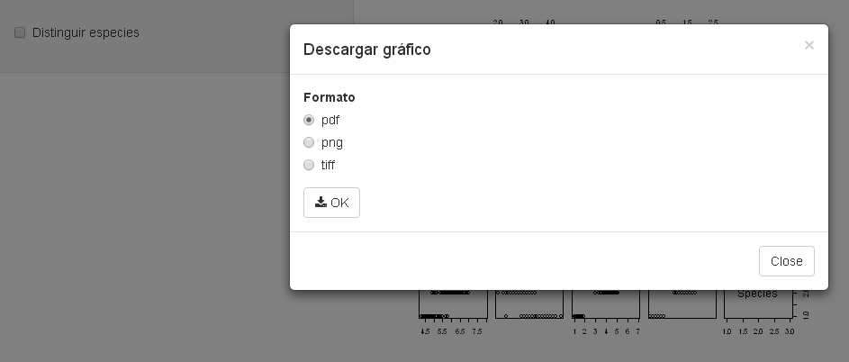

**UI:**

```r
library(shinyBS)

ui <- fluidPage(

  sidebarLayout(

    sidebarPanel(
      checkboxInput("grupos",
                    "Distinguir especies")
    ),

    mainPanel(
      plotOutput("grafico"),

      bsModal("modal",
              "Descargar gráfico",
              "grafico",
        radioButtons("tipo", "Formato",
                     c("pdf", "png", "tiff")),
        downloadButton("down", "OK")
      )

    )
  )
)
```

**Ejercicio:** Haz que aparezca un “popup” al colocar el puntero encima del gráfico, para guardarlo.

**Server:**

```r
server <- function(input, output) {

   output$grafico <- renderPlot({
     if (input$grupos)
       pairs(iris, col = iris[,5])
     else
       pairs(iris)
   }, width = 500)

   output$down <- downloadHandler(
     filename = function(){
       paste("grafico", input$tipo, sep = ".")
     },
     content = function(ff){
      if (input$tipo == "pdf") pdf(ff)
      if (input$tipo == "png") png(ff)
      if (input$tipo == "tiff") tiff(ff)
      if (input$grupos)
        pairs(iris, col = iris[,5])
      else
        pairs(iris)
      dev.off()
     }
   )
}
```

### Colapsables

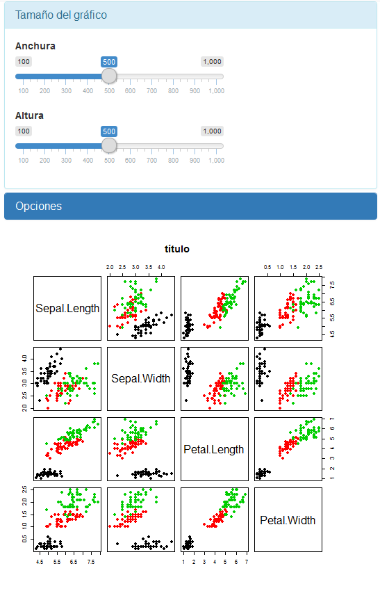

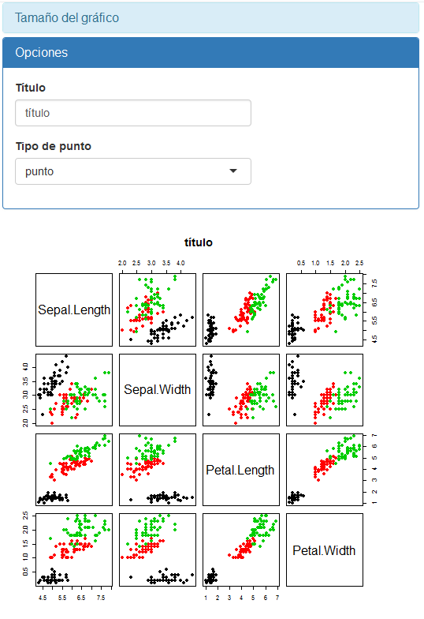

```r
library(shinyBS)
ui <- fluidPage(

  bsCollapse(id = "collapseExample", open = "Tamaño del gráfico",
    bsCollapsePanel("Tamaño del gráfico",
      sliderInput("width", "Anchura", 100, 1000, 500, 50),
      sliderInput("height", "Altura", 100, 1000, 500, 50)
    , style = "info"),
    bsCollapsePanel("Opciones",
      textInput("main", "Título", "título"),
      selectInput("pch", "Tipo de punto",
                  c("punto"=19, "cuadrado"=22, "diamante"=23))
    , style = "primary")
  ),

  uiOutput("result")
)

server <- function(input, output) {
  output$plot <- renderPlot({
    pairs(iris[,-5], col=iris[,5],
          main = input$main,
          pch = as.double(input$pch))
  })
  output$result <- renderUI({
    plotOutput("plot", width=input$width, height=input$height)
  })
}

runApp(list(ui=ui,server=server))
```

**Ejercicio**: cambia el argumento `multiple` de la función `bsCollapse` a `TRUE`.

### Toogle, show, hide

- El package **`shinyjs`** permite distintos efectos:
  - Esconder/mostrar elementos/textos (*toggle*)
  - Habilitar/deshabilitar botones
  - ….
- Está disponible en CRAN:

```r
install.packages(shinyjs)
```

- Para ver las posibilidades, visita esta [web](http://daattali.com/shiny/shinyjs-demo/)

### Ejemplo 1. Botones

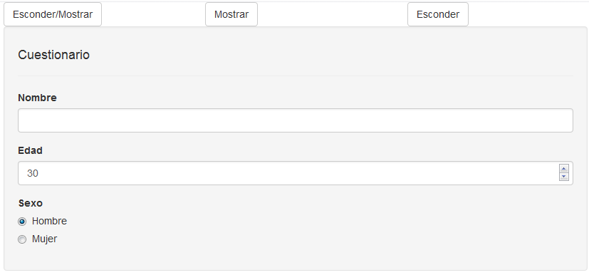

**UI**

```r
ui <- fluidPage(

  useShinyjs(),  # Set up shinyjs

  fluidRow(
    column(4, actionButton("btntoggle",
                           "Esconder/Mostrar")),
    column(4, actionButton("btnshow", "Mostrar")),
    column(4, actionButton("btnhide", "Esconder"))
  ),

  hidden(
    wellPanel(id="elemento",
      h4("Cuestionario"),
      hr(),
      textInput("nombre", "Nombre", ""),
      numericInput("edad", "Edad", 30),
      radioButtons("sexo", "Sexo", c("Hombre", "Mujer"))
    )
  )
)
```

**Server**

```r
server <- function(input, output, session) {

  observeEvent(input$btntoggle, {
    shinyjs::toggle("elemento", TRUE, "fade")
  })

  observeEvent(input$btnshow, {
    shinyjs::show("elemento", TRUE, "slide")
  })

  observeEvent(input$btnhide, {
    shinyjs::hide("elemento", FALSE)
  })

}
```

### Ejemplo 2. Password

- Hacer una aplicación visible cuando se introduce el password correcto
- Una vez introducido el password correcto hay que hacer desaparecer las ventanas de password y verificaciónd de password

```r
ui <- fluidPage(

  useShinyjs(),

  div(id="passScreen",
    passwordInput("pass","Password",""),
    actionButton("valida","Valida")
  ),

  shinyjs::hidden(
    div(id="miapp",
      titlePanel("Hello Shiny!"),
      sidebarLayout(
        sidebarPanel(
          sliderInput("obs","Number obs.",
              min=1,max=1000,value=500)
        ),
        mainPanel(
          plotOutput("distPlot")
        )
      )
    )
  )
)
```

```r
server <- function(input, output) {

  observeEvent(input$valida, {
    if (input$pass=='123'){
      shinyjs::show("miapp", FALSE)
      shinyjs::hide("passScreen", FALSE)
    } else {
      shinyjs::hide("miapp", FALSE)
      shinyjs::show("passScreen", FALSE)
    }
  })

  output$distPlot <- renderPlot({
    hist(rnorm(input$obs))
  })

}
```

[Pruébalo aquí](http://apps.datarus.eu/cursShiny/Bloque4Password/)

### Plantillas ("Themes")

**UI**

```r
library(shinythemes)

ui <- fluidPage(

  theme = shinytheme("united"), # especifica el CSS

  titlePanel("Example Shiny web"),
  sidebarLayout(
    sidebarPanel(
      selectInput("dataset", "Choose a dataset:",
                  c("rock", "pressure", "cars")),
      numericInput("obs",
              "Number of observations to view:", 10),
      helpText("Note: while the data view will
               show only the specified",
               "number of observations,
               the summary will still be based",
               "on the full dataset."),
      submitButton("Update View")
    ),
    mainPanel(
      tabsetPanel(type="pills",
        tabPanel("Summary",
          verbatimTextOutput("summary")
        ),
        tabPanel("Observations",
          tableOutput("view")
        )
      )
    )
  )
)
```

**Server**

```r
server <- function(input, output) {
  datasetInput <- reactive({
    switch(input$dataset,
           "rock"=rock, "pressure"=pressure, "cars"=cars)
  })
  output$summary <- renderPrint({
    dataset <- datasetInput()
    summary(dataset)
  })
  output$view <- renderTable({
    head(datasetInput(), n = input$obs)
  })
}
```

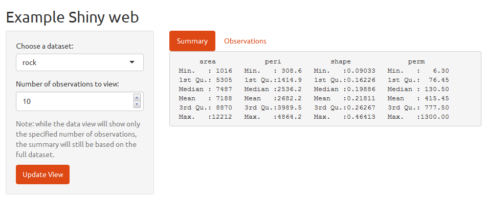

**EJERCICIOS:**

Cambia el argumento theme a otra plantilla.

Especifica un archivo CSS de la página http://bootswatch.com/

Ejercicio

### Ejercicio

A partir de la aplicación de la parte III ó II:

- Añade pop-ups.
- Modifica el aspecto de algún botón ó *frame* (`wellPanel` p.e.).
- crea colapsables.
- Incorpora una password.
- Cambia el aspecto mediante `shinythemes`.

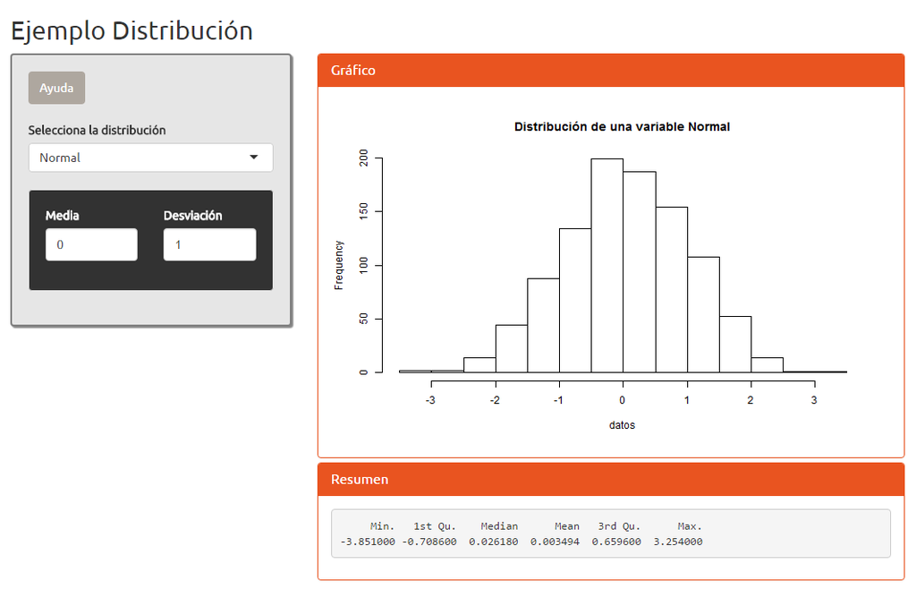